# Global Economic Growth Analysis (2000–2023)

Author

Faran Abbas

Published

August 4, 2025

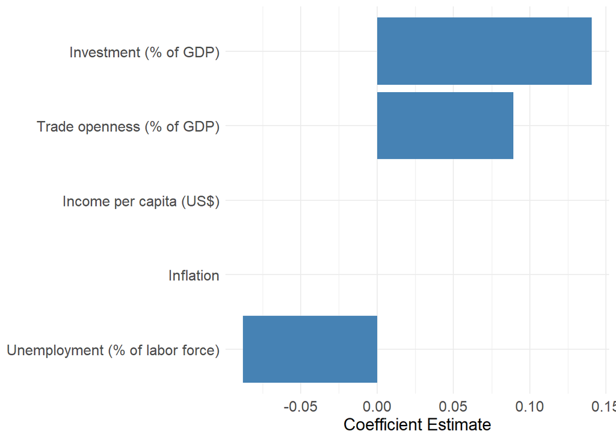

Impact of Key Factors on GDP Growth (2000–2023)

# Project Summary

What drives economic growth across countries from 2000 to 2023? This project uses data from the World Bank’s World Development Indicators, covering 2000 to 2023, to explore this question. The dataset, accessed via the WDI R package, was cleaned by removing missing values and standardizing variables like GDP growth (annual percentage change), income per capita (current US dollars), and trade openness (exports as a percentage of GDP). A fixed-effects panel model was employed to analyze GDP growth as the outcome variable, with covariates including income per capita, trade openness, investment, inflation, and unemployment. The model accounts for country and time-specific effects to ensure robust estimates. Higher investment levels, measured as gross capital formation, are strongly associated with increased GDP growth, underscoring their critical role in economic development.

# Data and Methods

The analysis leverages WDI data, focusing on:

- **Outcome**: GDP growth (annual %, `NY.GDP.MKTP.KD.ZG`)
- **Covariates**:
  - GNI per capita (current US$, `NY.GNP.PCAP.CD`)
  - Exports of goods and services (% of GDP, `NE.EXP.GNFS.ZS`)
  - Gross capital formation (% of GDP, `NE.GDI.TOTL.ZS`)
  - Consumer price index (2010 = 100, `FP.CPI.TOTL`)
  - Unemployment (% of total labor force, `SL.UEM.TOTL.ZS`)

Data is sourced via the `WDI` R package, with missing values removed for robustness. Two models are estimated: 1. A multiple linear regression for 2023 data. 2. A fixed-effects panel model for 2000–2023, accounting for country and time heterogeneity.

Results are visualized with regression tables and bar charts for accessibility.

## Cross-Sectional Analysis (2023)

### Data Preparation and Regression

Regression Results for GDP Growth (2023)

| term | estimate | std.error | statistic | p.value |
| --- | --- | --- | --- | --- |
| Intercept | 2.828 | 2.721 | 1.039 | 0.300 |
| GNI per capita (US$) | 0.000 | 0.000 | -0.514 | 0.608 |
| Exports (% of GDP) | 0.018 | 0.020 | 0.914 | 0.362 |
| Capital formation (% of GDP) | 0.023 | 0.085 | 0.275 | 0.783 |
| Consumer price index | 0.000 | 0.001 | -0.300 | 0.765 |
| Unemployment (% of labor force) | -0.058 | 0.119 | -0.490 | 0.625 |

### Visualization

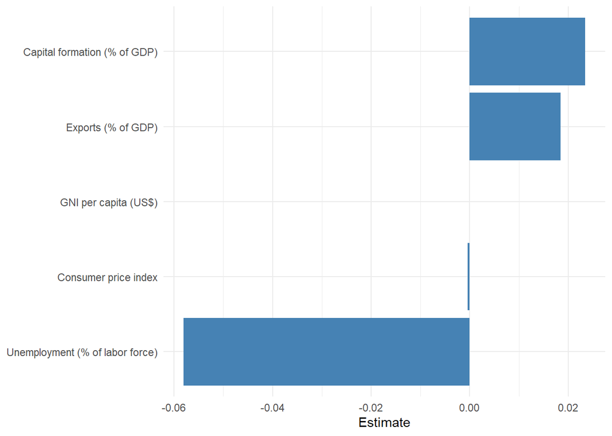

Coefficient Estimates for 2023 Cross-Sectional Model

## Panel Data Analysis (2000–2023)

Fixed Effects Regression Results for GDP Growth (2000–2023)

| term | estimate | std.error | statistic | p.value |
| --- | --- | --- | --- | --- |
| GNI per capita (US$) | 0.000 | 0.000 | -0.346 | 0.730 |
| Exports (% of GDP) | 0.089 | 0.009 | 9.590 | 0.000 |
| Capital formation (% of GDP) | 0.141 | 0.015 | 9.121 | 0.000 |
| Consumer price index | 0.000 | 0.000 | -0.465 | 0.642 |
| Unemployment (% of labor force) | -0.088 | 0.037 | -2.356 | 0.019 |